# 732A90 Lab 2

Daniele Bozzoli & Hugo Morvan

2023-11-14

## Question 1: Optimisation of a two-dimensional function

### a)

Countour plot:

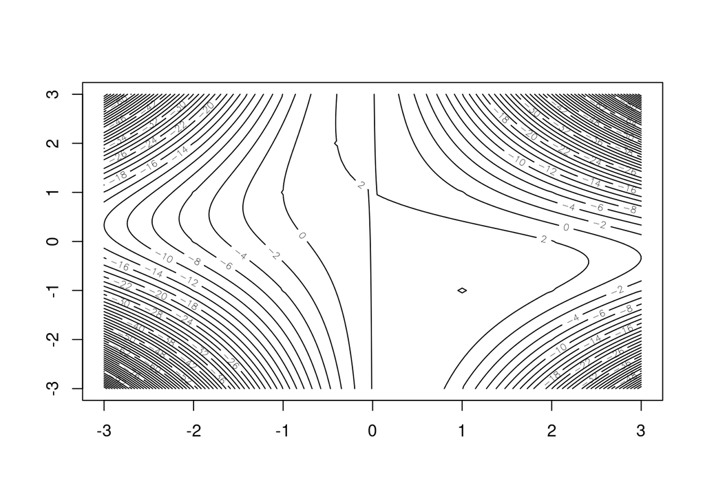

### b)

```r
newton <- function(x, epsilon){
  #x is the starting vector
  dist <- 999

  while(dist > epsilon){
    gp <- get_gradient(x)
    gpp <- get_hessian(x)
    x_next <- x - solve(gpp)%*%gp
    dist <- sum((x-x_next)*(x-x_next))
    x <- x_next
  }
  return(x)
}
```

### c)

Starting point : (x, y) = (2, 0), Newton method output : (1, -1).

Starting point : (x, y) = (-1, -2), Newton method output : (0, 1).

Starting point : (x, y) = (0, 1), Newton method output : (0, 1).

Starting point : (x, y) = (10, -10), Newton method output : (1, -1).

We obtain 2 points : (0,1) and (1,-1). The Gradient for the point (0,1) is (0, 0) and its Hessian matrix is:

```
##      [,1] [,2]
## [1,]   -4   -2
## [2,]   -2    0
```

The Gradient for the point (1,-1) is (0, 0) and its Hessian matrix is:

```
##      [,1] [,2]
## [1,]   -4    2
## [2,]    2   -2
```

The matrix is a negative definite therefore this is a local maximum.

### d)

The disadvantage of using the steepest method instead of the Newton one is that it converges slower, but the advantage is that the computation of the Hessian matrix is not needed, which can be difficult sometimes to calculate.

## Question 2:

### a)

```r
X <- c(0,0,0,0.1,0.1,0.3,0.3,0.9,0.9,0.9)
Y <- c(0,0,1,0,1,1,1,0,1,1)

g <- function(B){
  sum1 <- 0
  for (q in 1:10)
    sum1 <- sum1 + (Y[q]*log((1+exp(-B[1]-B[2]*X[q]))^-1)+(1-Y[q])*log(1-(1+exp(-B[1]-B[2]*X[q]))^-1))
  return(sum1)
}

grad <- function(B){
  sum2 <- c(0,0)
  for (i in 1:10)
    sum2 <- sum2 + ((Y[i] - (1/(1+exp(-B[1]-B[2]*X[i])))) * c(1,X[i]))
  return(sum2)
}

steepestasc <- function(x0, eps=1e-6, alpha0=1){
  countfun <- 0
  countgrad <- 0
  xt   <- x0
  conv <- 999
  while(conv > eps){
    alpha <- alpha0
    xt1   <- xt
    xt    <- xt1 + alpha*grad(xt1)
    countgrad <- countgrad + 1
    while (g(xt) < g(xt1)){
      countfun <- countfun + 2
      alpha <- alpha/2
      xt    <- xt1 + alpha*grad(xt1)
      countgrad <- countgrad + 1
    }
    conv <- sum((xt-xt1)*(xt-xt1)) # convergence criterion: distance between two successive iterates
  }
  cat(xt, "\n")
  cat("Function calls:", countfun, "\nGradiant calls:", countgrad,"\n")
}
```

### b)

Using Alpha = 1, the optimal point is found at :

```
## -0.008418083 1.260523
## Function calls: 18
## Gradiant calls: 28
```

Using Alpha = 5, the optimal point is found at :

```
## -0.008803282 1.260276
## Function calls: 114
## Gradiant calls: 77
```

We reach the same result, but with less function calls and gradient calls for a backtracking starting value of Alpha = 1.

### c)

optim function with Nelder-Mead method:

```r
g2 <- function(B){
  sum1 <- 0
  for (q in 1:10)
    sum1 <- sum1 + (Y[q]*log((1+exp(-B[1]-B[2]*X[q]))^-1)+(1-Y[q])*log(1-(1+exp(-B[1]-B[2]*X[q]))^-1))
  return(-sum1)
}

optim(c(-0.2, 1), g2, method= "Nelder-Mead")
```

```
## $par
## [1] -0.009423433  1.262738266
##
## $value
## [1] 6.484279
##
## $counts
## function gradient
##       47       NA
##
## $convergence
## [1] 0
##
## $message
## NULL
```

optim function with BFGS method:

```r
optim(c(-0.2, 1), g2, method= "BFGS")
```

```
## $par
## [1] -0.009356112  1.262812883
##
## $value
## [1] 6.484279
##
## $counts
## function gradient
##       12        8
##
## $convergence
## [1] 0
##
## $message
## NULL
```

### d)

```r
glm(Y~X,family = "binomial")
```

```
##
## Call:  glm(formula = Y ~ X, family = "binomial")
##
## Coefficients:
## (Intercept)            X
##    -0.00936      1.26282
##
## Degrees of Freedom: 9 Total (i.e. Null);  8 Residual
## Null Deviance:       13.46
## Residual Deviance: 12.97     AIC: 16.97
```

We get the same result as the glm function. Great!

## Appendix:

### 1-a)

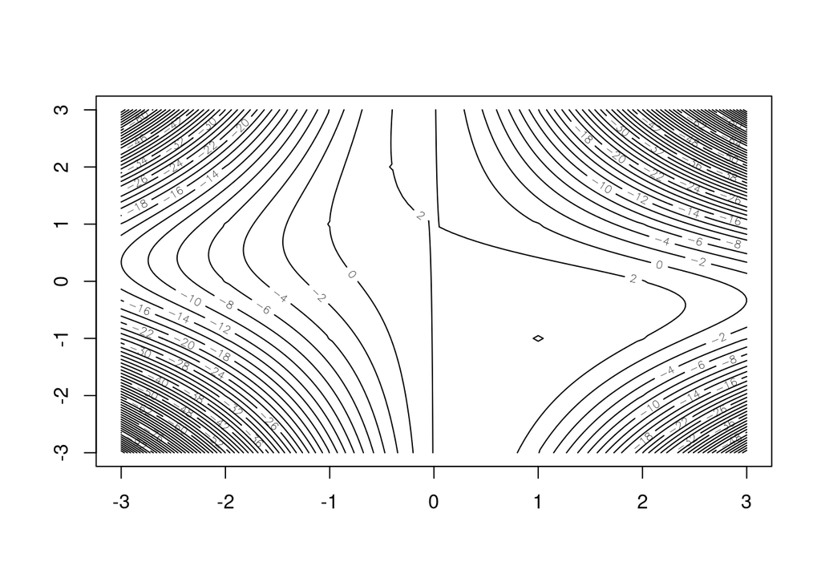

```r
f <- function(p){
  x <- p[1]
  y <- p[2]
  return(-x^2 -x^2*y^2 -2*x*y +2*x +2)
}
f_x <- function(p){
  x <- p[1]
  y <- p[2]
  return(-2*x -2*x*y^2 -2*y +2)
}
f_y <- function(p){
  x <- p[1]
  y <- p[2]
  return(-2*x^2*y-2*x)
}
f_xy <- function(p){
  x <- p[1]
  y <- p[2]
  return(-4*x*y-2)
}
f_xx <- function(p){
  x <- p[1]
  y <- p[2]
  return(-2 -2*y^2)
}
f_yy <- function(p){
  x <- p[1]
  y <- p[2]
  return(-2*x^2)
}
get_gradient <- function(p){
  return(c(f_x(p), f_y(p)))
}
get_hessian <- function(p){
  hess <- matrix(c(f_xx(p), f_xy(p), f_xy(p), f_yy(p)), ncol=2)
  return(hess)
}

x <- seq(-3,3,0.05)
y <- seq(-3,3,0.05)

lx <- length(x)
ly <- length(y)

points1 <- matrix(0,nrow=lx, ncol=ly)

for (i in 1:lx){
  for (q in 1:ly){
    points1[i,q] <- f(c(x[i], y[q]))
  }
}
contour(x,y,points1, nlevels=50)
```

### 1-b)

```r
newton <- function(x, epsilon){
  #x is you starting vector
  dist <- 999

  while(dist > epsilon){
    gp <- get_gradient(x)
    gpp <- get_hessian(x)
    x_next <- x - solve(gpp)%*%gp
    dist <- sum((x-x_next)*(x-x_next))
    x <- x_next
  }
  return(x)
}
```

### 1-c)

```r
p1 <- c(2,0)
p2 <- c(-1,-2)
p3 <- c(0,1)
p4 <- c(10,-10)
epsilon <- 1E-8
newton(p1, epsilon)
```

```
##      [,1]
## [1,]    1
## [2,]   -1
```

```r
newton(p2, epsilon)
```

```
##              [,1]
## [1,] 1.361391e-22
## [2,] 1.000000e+00
```

```r
newton(p3, epsilon)
```

```
##      [,1]
## [1,]    0
## [2,]    1
```

```r
newton(p4, epsilon)
```

```
##      [,1]
## [1,]    1
## [2,]   -1
```

```
## [1] "Gradient and Hessian for the point (0,1)"
```

```
## [1] 0 0
```

```
##      [,1] [,2]
## [1,]   -4   -2
## [2,]   -2    0
```

```
## [1] "this is a saddle point"
```

```
## [1] "Gradient and Hessian for the point (1,-1)"
```

```
## [1] 0 0
```

```
##      [,1] [,2]
## [1,]   -4    2
## [2,]    2   -2
```

```
## [1] "this is a maximum"
```

### 2-a)

```r
X <- c(0,0,0,0.1,0.1,0.3,0.3,0.9,0.9,0.9)
Y <- c(0,0,1,0,1,1,1,0,1,1)

g <- function(B){
  sum1 <- 0
  for (q in 1:10)
    sum1 <- sum1 + (Y[q]*log((1+exp(-B[1]-B[2]*X[q]))^-1)+(1-Y[q])*log(1-(1+exp(-B[1]-B[2]*X[q]))^-1))
  return(sum1)
}

grad <- function(B){
  sum2 <- c(0,0)
  for (i in 1:10)
    sum2 <- sum2 + ((Y[i] - (1/(1+exp(-B[1]-B[2]*X[i])))) * c(1,X[i]))
  return(sum2)
}

steepestasc <- function(x0, eps=1e-8, alpha0=1)
{
  countfun <- 0
  countgrad <- 0
  xt   <- x0
  conv <- 999
  while(conv > eps)
  {
    alpha <- alpha0
    xt1   <- xt
    xt    <- xt1 + alpha*grad(xt1)
    countgrad <- countgrad + 1
    while (g(xt) < g(xt1))
    {
      countfun <- countfun + 2
      alpha <- alpha/2
      xt    <- xt1 + alpha*grad(xt1)
      countgrad <- countgrad + 1
    }
    conv <- sum((xt-xt1)*(xt-xt1))
  }
  cat(xt, "\n")
  cat("Function calls:", countfun, "\nGradiant calls:", countgrad,"\n")
}
```

### 2-b)

Using Alpha = 1 :

```r
steepestasc(c(-0.2, 1))
```

```
## -0.009316239 1.262656
## Function calls: 26
## Gradiant calls: 43
```

Using Alpha = 5 :

```r
steepestasc(c(-0.2, 1), alpha0=5)
```

```
## -0.009327714 1.262664
## Function calls: 180
## Gradiant calls: 122
```

We reach the same result, but with less function calls and gradient calls.

### 2-c)

```r
g2 <- function(B){
  sum1 <- 0
  for (q in 1:10)
    sum1 <- sum1 + (Y[q]*log((1+exp(-B[1]-B[2]*X[q]))^-1)+(1-Y[q])*log(1-(1+exp(-B[1]-B[2]*X[q]))^-1))
  return(-sum1)
}

optim(c(-0.2, 1), g2, method= "Nelder-Mead")
```

```
## $par
## [1] -0.009423433  1.262738266
##
## $value
## [1] 6.484279
##
## $counts
## function gradient
##       47       NA
##
## $convergence
## [1] 0
##
## $message
## NULL
```

```r
optim(c(-0.2, 1), g2, method= "BFGS")
```

```
## $par
## [1] -0.009356112  1.262812883
##
## $value
## [1] 6.484279
##
## $counts
## function gradient
##       12        8
##
## $convergence
## [1] 0
##
## $message
## NULL
```

### 2-d)

```r
glm(Y~X,family = "binomial")
```

```
##
## Call:  glm(formula = Y ~ X, family = "binomial")
##
## Coefficients:
## (Intercept)            X
##    -0.00936      1.26282
##
## Degrees of Freedom: 9 Total (i.e. Null);  8 Residual
## Null Deviance:       13.46
## Residual Deviance: 12.97     AIC: 16.97
```